# Inmigración y Delitos en España (2010–2023) — Informe Final

Jesús Castro

2025-10-27

[figure not shown]

## 0.1 Contexto y alcance del estudio

El proyecto **“Delitos e Inmigración en España (2010–2023)”** nació con la intención original de analizar la evolución conjunta de la **criminalidad y la inmigración en España desde 1998** hasta la actualidad.

Sin embargo, la **falta de desagregación por nacionalidad antes de 2010** en los registros del *Ministerio del Interior* y la discontinuidad en las series de población extranjera del *INE* hicieron **imposible construir un panel homogéneo anterior a 2010**.

Por esta razón, el periodo final del estudio se **delimitó a 2010–2023**, garantizando **consistencia anual**, **coherencia estadística** y **comparabilidad entre fuentes oficiales (INE, Interior y Eurostat)**.

> Este marco temporal permite capturar la consolidación de la inmigración en España, la recuperación post-crisis de 2008 y el impacto de los años de COVID-19 (2020–2021), ofreciendo una visión equilibrada entre estabilidad estructural y eventos extraordinarios.

## 0.2 Pregunta de investigación

> **¿Existe una relación descriptiva significativa entre la variación en la población extranjera y la variación en la tasa de delitos en España entre 2010 y 2023?**

Esta pregunta guía el análisis empírico del proyecto y enmarca todos los resultados dentro de un enfoque **descriptivo y no causal**, centrado en observar co-movimientos estadísticos y patrones de correlación en el tiempo.

## 0.3 Ficha técnica del estudio

Estudio reproducible desarrollado íntegramente en **R y RStudio** (versión ≥ 4.3), siguiendo un flujo completo de análisis de datos: limpieza, validación, generación de métricas, visualización y reporte automatizado en **RMarkdown/Quarto**.  
El entorno fue gestionado con **renv** para asegurar la **reproducibilidad exacta** del entorno de ejecución y las dependencias de los paquetes.

El proyecto analiza el periodo **2010–2023**, evaluando la relación entre **población extranjera** y **criminalidad agregada en España**.  
Incluye **controles socioeconómicos** (PIB real, AROPE, paro juvenil) y **ventanas de análisis con y sin COVID-19**.  
Los resultados son **descriptivos y no causales**, basados exclusivamente en **fuentes oficiales** (INE, Ministerio del Interior y Eurostat).

Todas las figuras y tablas fueron generadas con **ggplot2** y **paquetes del ecosistema tidyverse**, bajo un diseño visual coherente (tema “pearl” y paleta Okabe–Ito).  
El informe se produce automáticamente a partir de los datos procesados mediante scripts versionados y trazables dentro del repositorio.

**Autor:** Jesús Castro · JESUSCASTRODATA  
**Entorno:** R + RStudio · renv reproducible · ggplot2 + tidyverse  
**Periodo:** 2010–2023 · **Versión:** dev · **Últ. actualización:** 2025-10-27  
**Licencias:** MIT (código) · CC BY 4.0 (documentos y figuras)  
**Repositorio:** github.com/JESUSCASTRODATA/crime-migration-spain

# 1 Resumen ejecutivo

Cobertura. 2010–2023 (análisis principal con y sin 2020–2021). Fuentes. INE (población), Ministerio del Interior (criminalidad), Eurostat (Gini y AROPE; serie armonizada UE). Métricas. Tasas por 100k, % de población extranjera, diferencias interanuales (Δ). Aviso. Evidencia descriptiva; no implica causalidad.

**Hallazgos clave.**

# 2 Datos y metodología

## 2.1 Fuentes y cobertura

- Ámbito temporal: 2010–2023 (Total Nacional, España), frecuencia anual.
- Fuentes oficiales: INE (población residente), Ministerio del Interior (HC/HE), Eurostat (Gini y AROPE) como contexto/controles.
- Ventanas analíticas: (i) **Total** 2010–2023 (incluye COVID); (ii) **Sin COVID** 2010–2019 & 2022–2023.

## 2.4 Tratamiento de COVID‑19

- **Motivación:** 2020–2021 introduce un shock exógeno (movilidad, denuncias, operativa policial).
- **Estrategia:** mostrar resultados **con** y **sin** esos años; la ventana sin COVID es referencia para Δ.

## 2.5 Chequeos de calidad (QC)

- Cobertura temporal por variable; no‑negatividad y rangos plausibles.
- Consistencia contable (Total Nacional vs suma CCAA, cuando aplica).
- Duplicados y claves únicas (variable, año).
- Coherencia HC/HE (HE no debe exceder sistemáticamente HC).
- Evidencia de QA: tablas `*_summary`, `*_qa_*` documentan cada chequeo.

## 2.6 Métodos estadísticos

- Correlaciones bivariadas: **Pearson (r)**, **Spearman (ρ)**, **Kendall (τ)** con p‑valores y n.
- Correlaciones parciales: controlando composición demográfica (p. ej., share_extranjeros, AROPE, paro juvenil) para aislar la relación neta entre inmigración y criminalidad. Además de su función técnica de control, se utilizan para evaluar hasta qué punto la asociación entre ambas variables podría explicarse por factores comunes, reforzando la interpretación no causal del análisis.
- Estacionariedad: tests **ADF, PP, KPSS** en niveles y en Δ (resúmenes α = 5% y 10%).
- Precedencia temporal (exploratoria): **Toda–Yamamoto (TY)** y **Granger**; interpretar con cautela por muestra corta y ruptura COVID.

## 2.7 Reporte y reproducibilidad

Este documento **no recalcula**: inserta figuras/tablas ya exportadas. Rutas relativas desde `docs/` → `../output/figures/` y `../output/tables/`.

**Convenciones**

- Figuras: `01_tendencias_base100.png`, `03_corr_deltas_sin_covid.png`, `18_stationarity_heatmap.png`…
- Tablas: `20_corr_deltas_sin_covid.csv`, `20_pcor_niveles_sin_covid.csv`, `18_stationarity_summary.csv`…

## 2.8 Limitaciones técnicas

Muestra anual corta (14 obs.); agregación nacional; posibles variables omitidas; ruptura COVID. Se prioriza evidencia en Δ y ventana sin COVID.

## 2.9 Notación

`d_` = Δ (primera diferencia anual). `pct_` = porcentaje (0–100); `share_` = proporción (0–1). `*_100k` = tasa por 100.000 hab. `r, ρ, τ` = Pearson, Spearman, Kendall.

# 3 Resultados descriptivos — Niveles y variaciones

## 3.1 Tendencias base-100: Hechos conocidos, esclarecidos y % extranjeros

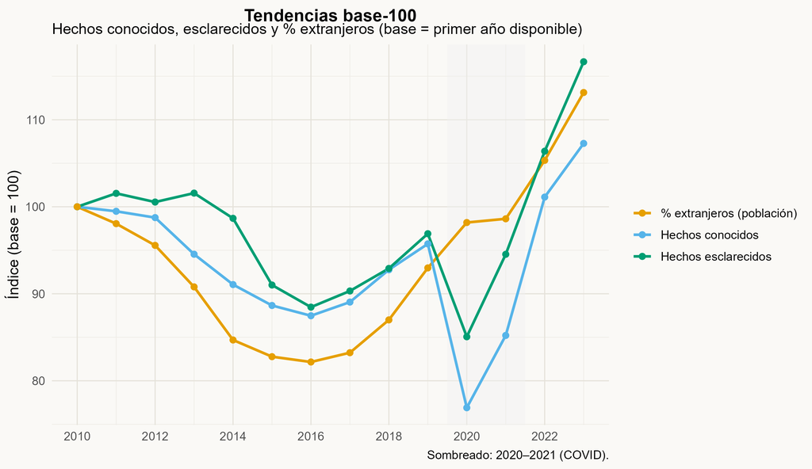

Tendencias base-100: Hechos conocidos, esclarecidos y % extranjeros (base = primer año disponible)

## 3.2 Correlaciones en variaciones — sin COVID (2010–2019 & 2022–2023)

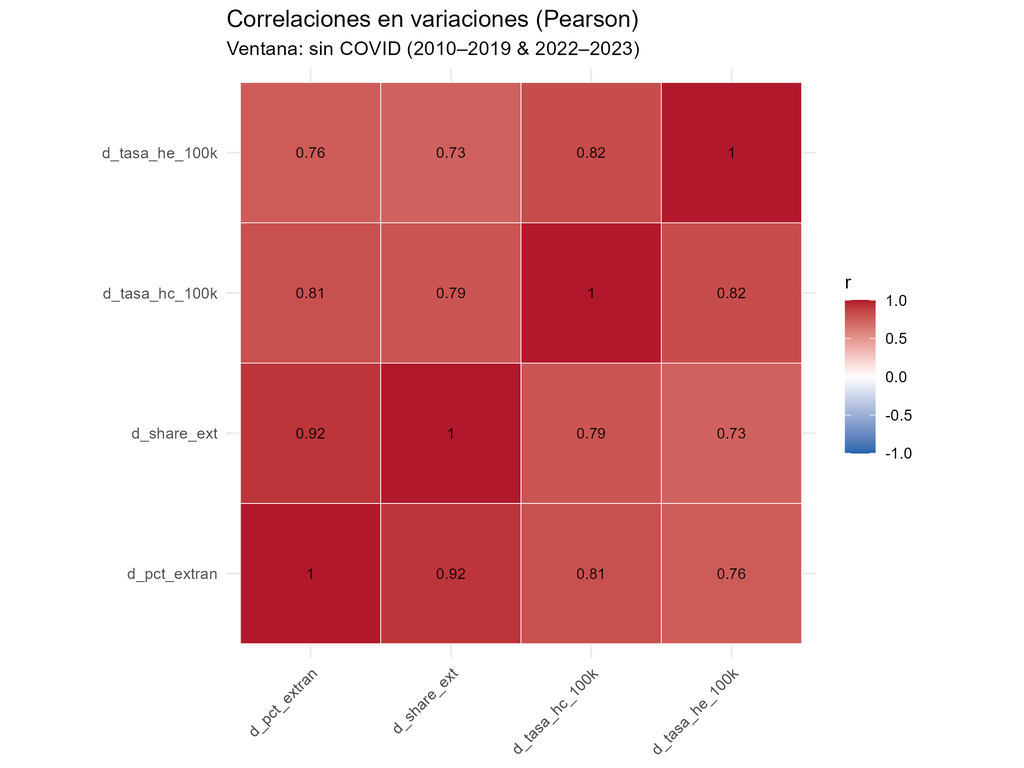

Correlaciones en variaciones (Δ) — ventana sin COVID

## 3.3 Correlaciones en variaciones — ventana total (2010–2023)

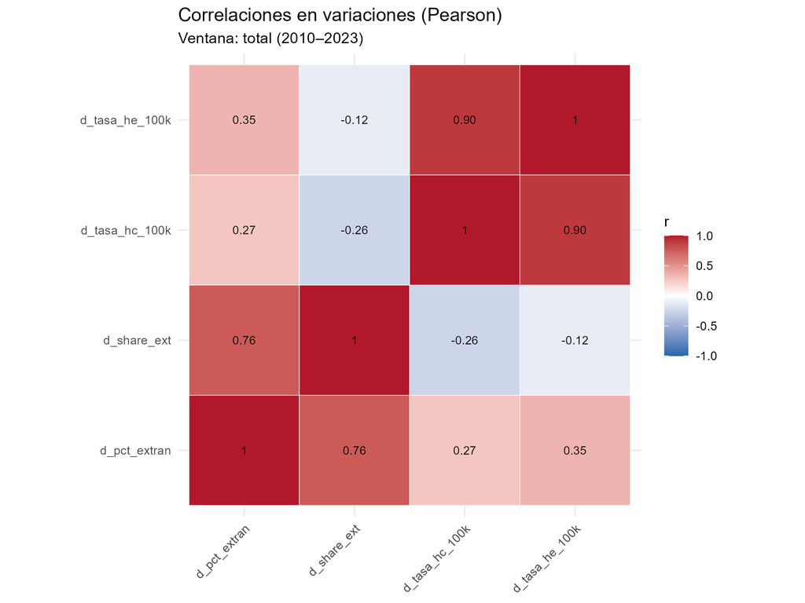

Correlaciones en variaciones (Δ) — ventana total (2010–2023)

## 3.4 Δ HC por 100k vs Δ % extranjeros — todo el periodo

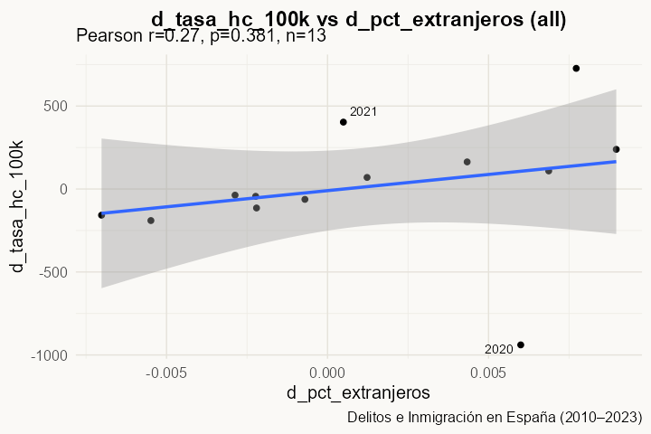

Δ HC por 100k vs Δ % extranjeros — todo el periodo

> Esta figura representa la relación entre los cambios anuales (Δ) en la tasa de *hechos conocidos* por 100.000 habitantes y la variación anual en el porcentaje de población extranjera, para todo el periodo 2010–2023.

> Al incluir los años 2020–2021 (marcados por el impacto del COVID-19), la asociación lineal se debilita (*r* ≈ 0.27, *p* ≈ 0.38), reflejando un aumento de la volatilidad y una pérdida de co-movilidad respecto a la ventana sin COVID.

> En términos descriptivos, el comportamiento atípico de 2020 y 2021 reduce la fuerza de la relación observada entre ambas variables.

## 3.5 Δ (5 delitos) vs Δ % extranjeros — excluye 2020–2021

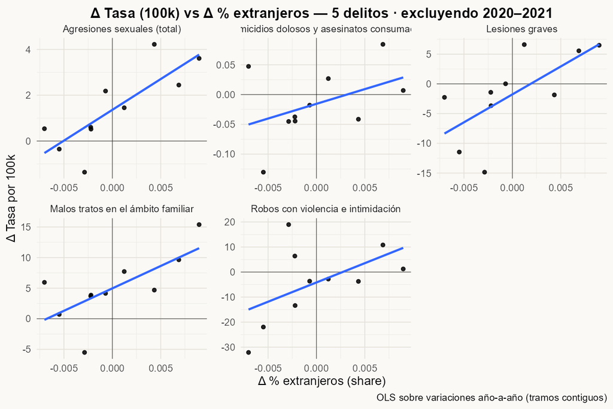

Δ (5 delitos) vs Δ % extranjeros — excluye 2020–2021

> Cada panel representa la variación interanual de la tasa (por 100.000 habitantes) frente al cambio en el porcentaje de población extranjera para una tipología concreta de delito violento.

> En la ventana sin COVID (2010–2019 y 2022–2023), las cinco tipologías muestran pendientes positivas: a medida que aumenta la proporción de extranjeros, también lo hace la tasa de estos delitos.

> No obstante, las relaciones son descriptivas y deben interpretarse como **coevolución temporal**, no causalidad. Las tendencias podrían reflejar factores estructurales comunes, como cambios en la denuncia, la actividad económica o el control policial.

## 3.6 Δ (5 delitos) vs Δ % extranjeros — con 2020–2021

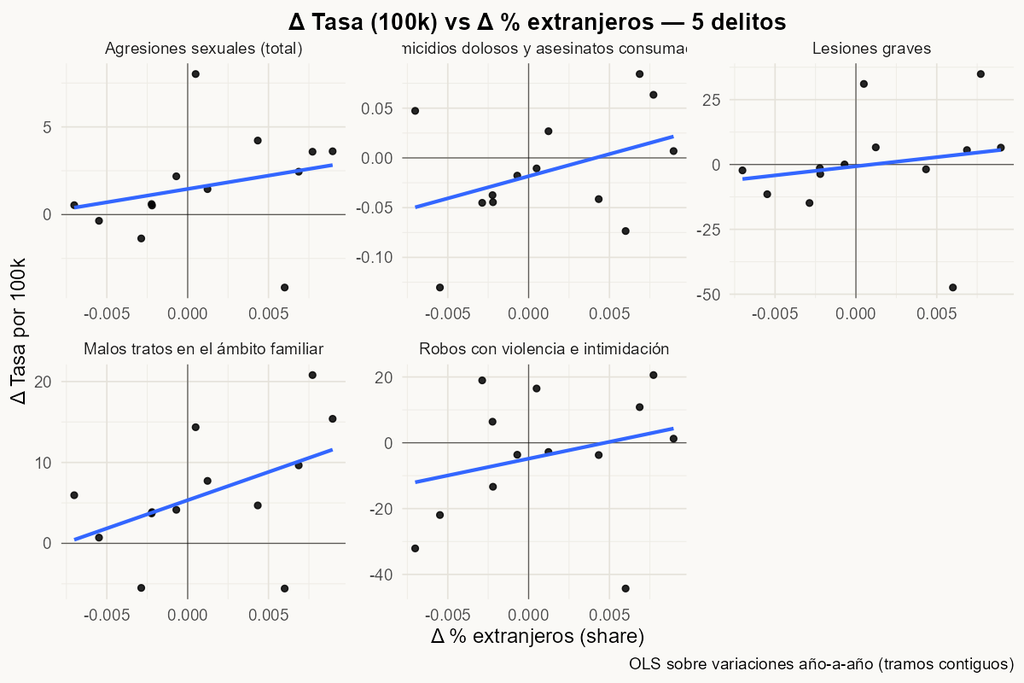

Δ (5 delitos) vs Δ % extranjeros — con 2020–2021

> Al incluir los años **2020–2021**, el patrón de relación entre las variaciones en el porcentaje de población extranjera y las tasas de los cinco delitos seleccionados se vuelve **más irregular y disperso**. La pendiente positiva se atenúa, lo que indica que durante la pandemia —un periodo excepcional en movilidad, denuncias y operatividad policial— las series **perdieron sincronía temporal**, reduciendo la fuerza de la coevolución observada en periodos previos y posteriores.

## 3.7 Niveles: tasa HC (100k) vs % extranjeros — sin COVID

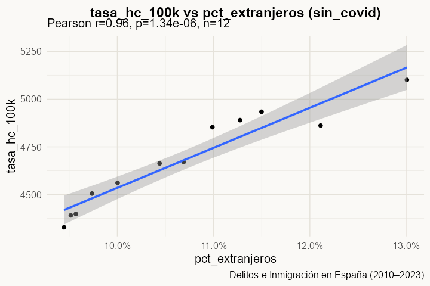

Niveles: tasa HC (100k) vs % extranjeros — sin COVID

> Al excluir los años 2020–2021, la relación entre la tasa de *Hechos Conocidos* y el porcentaje de población extranjera es muy alta (*r* ≈ 0.96). Este resultado refleja una coevolución casi lineal en niveles, aunque no necesariamente causal, probablemente explicada por factores estructurales comunes como el crecimiento demográfico y la recuperación económica tras la crisis de 2008.

## 3.8 Niveles: tasa HC (100k) vs % extranjeros — todo el periodo

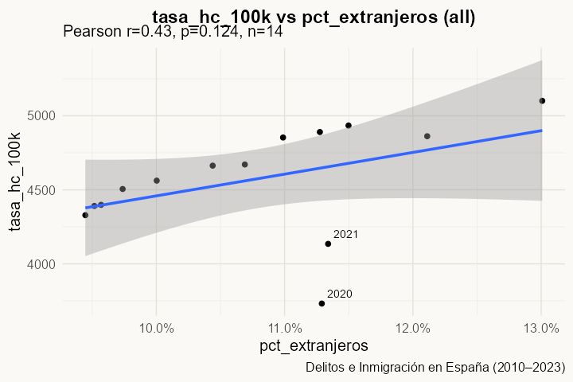

Niveles: tasa HC (100k) vs % extranjeros — todo el periodo

> En el periodo completo **2010–2023**, la relación entre la tasa de *hechos conocidos* (HC) y el porcentaje de población extranjera mantiene **una pendiente positiva moderada (r≈0.43)**. Sin embargo, los años **2020–2021** destacan como **outliers negativos**, reflejando la distorsión estadística causada por la pandemia (menor movilidad y variación en registros). Al excluirlos (véase la figura anterior *“sin COVID”*), la asociación se refuerza notablemente, mostrando un patrón de coevolución más claro entre ambas series.

## 3.9 Estacionariedad por ventana y transformación (α = 5%)

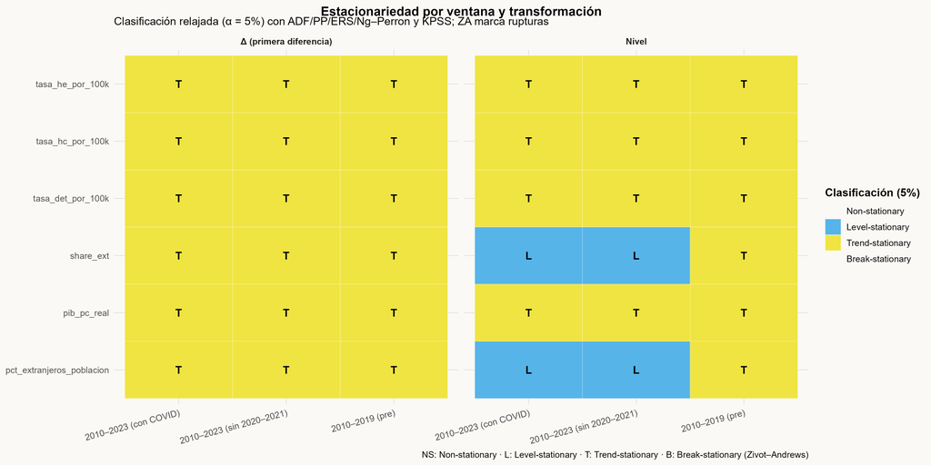

Estacionariedad por ventana y transformación (α = 5%)

## 3.10 Precedencia temporal en niveles (Toda–Yamamoto), FDR ≤ 10%

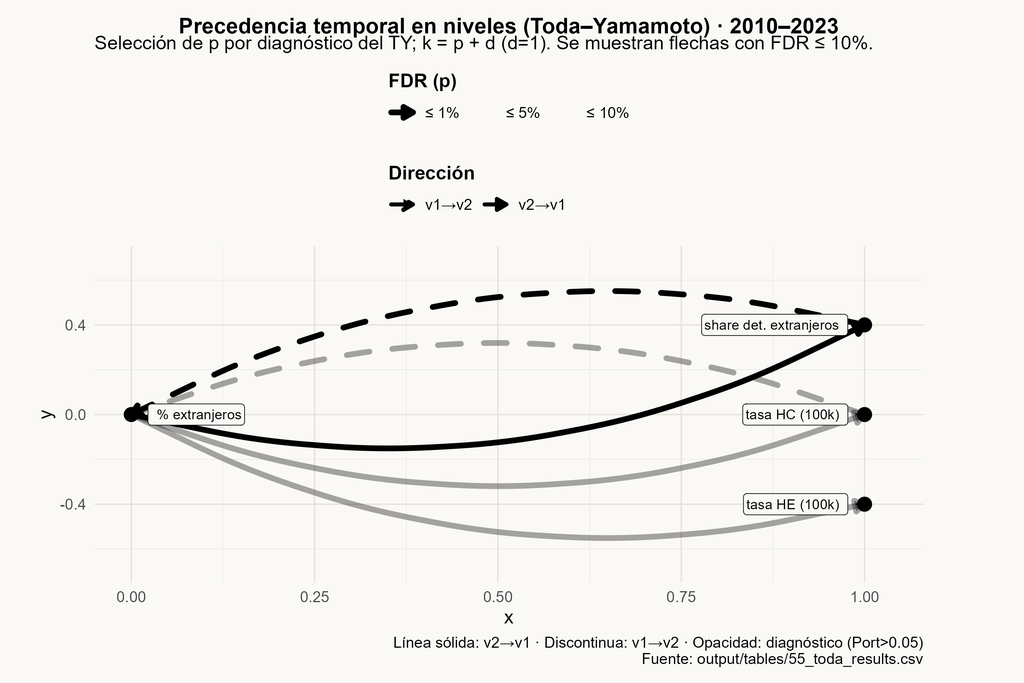

Precedencia temporal en niveles (Toda–Yamamoto), FDR ≤ 10%

> El gráfico representa los resultados del procedimiento **Toda–Yamamoto (1995)** aplicado a las series en niveles para el periodo 2010–2023. Las flechas muestran las direcciones donde se detecta precedencia temporal con **FDR (False Discovery Rate) ≤ 10%**.

> En este caso, no se observan relaciones causales unidireccionales estables: las conexiones entre el **% de extranjeros** y las tasas de **Hechos Conocidos (HC)** o **Hechos Esclarecidos (HE)** son **bidireccionales o débiles**, lo que sugiere **posible endogeneidad** o influencia de factores comunes. Esto refuerza la interpretación **no causal** del estudio: las co-variaciones detectadas describen patrones estadísticos, no mecanismos de causa-efecto comprobados.

# 4 Correlaciones y controles

**Convención:** Δx ≡ `d_x` en tablas (p. ej., Δ% extranjeros = `d_pct_extranjeros`).

Correlaciones (Pearson/Spearman/Kendall) en niveles — ventana sin COVID

| x | y | pearson_r | pearson_p | n | spearman_r | spearman_p | kendall_r | kendall_p |
| --- | --- | --- | --- | --- | --- | --- | --- | --- |
| pct_extranjeros | share_extranjeros | 0.9761 | 0e+00 | 12 | 0.9720 | 0e+00 | 0.9091 | 0.000 |
| pct_extranjeros | tasa_hc_100k | 0.9550 | 0e+00 | 12 | 0.9790 | 0e+00 | 0.9394 | 0.000 |
| pct_extranjeros | tasa_he_100k | 0.9032 | 1e-04 | 12 | 0.8741 | 2e-04 | 0.7273 | 0.001 |

Correlaciones (Pearson/Spearman/Kendall) en variaciones (Δ) — ventana sin COVID

| x | y | pearson_r | pearson_p | n | spearman_r | spearman_p | kendall_r | kendall_p |
| --- | --- | --- | --- | --- | --- | --- | --- | --- |
| d_pct_extranjeros | d_share_extranjeros | 0.9176 | 0.0001 | 11 | 0.9000 | 0.0002 | 0.7455 | 0.0014 |
| d_pct_extranjeros | d_tasa_hc_100k | 0.8086 | 0.0026 | 11 | 0.8909 | 0.0002 | 0.7091 | 0.0024 |
| d_pct_extranjeros | d_tasa_he_100k | 0.7566 | 0.0070 | 11 | 0.7455 | 0.0085 | 0.6000 | 0.0102 |

**Nota:** En Δ, la asociación entre Δ% extranjeros y ΔHC es fuerte al excluir 2020–2021 (p. ej., r≈0.81; ρ≈0.89).

Las **correlaciones parciales** permiten aislar la relación neta entre inmigración y criminalidad, descontando el efecto de variables económicas y demográficas (AROPE, PIB real y paro juvenil). En la siguiente figura se observa cómo, una vez controladas estas variables, la pendiente entre Δ% de extranjeros (en puntos porcentuales) y ΔHC por 100.000 habitantes **se reduce pero mantiene signo positivo**.

## 4.1 Visualización parcial: Δ% extranjeros (p.p.) vs ΔHC (100k) — sin COVID

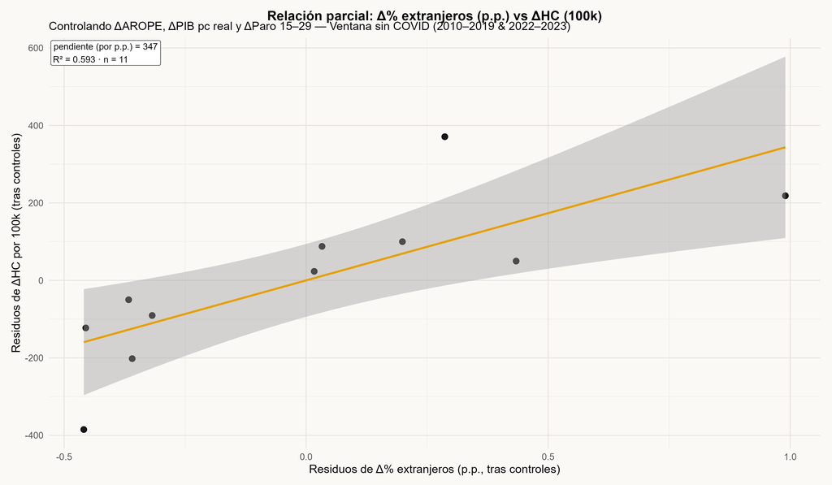

Relación parcial: Δ% extranjeros (p.p.) vs ΔHC (100k) — sin COVID (controlando ΔAROPE, ΔPIB pc real y ΔParo 15–29)

> La pendiente parcial ilustra cómo la asociación se **atenúa** tras controlar por AROPE, PIB pc real y paro juvenil.

Correlaciones parciales en niveles — controlando composición (sin COVID)

| x | y | n | method | r | p |
| --- | --- | --- | --- | --- | --- |
| pct_extranjeros | share_extranjeros | 12 | pearson | 0.9473 | 0e+00 |
| pct_extranjeros | share_extranjeros | 12 | spearman | 0.8811 | 2e-04 |
| pct_extranjeros | tasa_hc_100k | 12 | pearson | 0.9579 | 0e+00 |
| pct_extranjeros | tasa_hc_100k | 12 | spearman | 0.9021 | 1e-04 |
| pct_extranjeros | tasa_he_100k | 12 | pearson | 0.9196 | 0e+00 |
| pct_extranjeros | tasa_he_100k | 12 | spearman | 0.8462 | 5e-04 |

Correlaciones parciales en variaciones (Δ) — controlando composición (sin COVID)

| x | y | n | method | r | p |
| --- | --- | --- | --- | --- | --- |
| d_pct_extranjeros | d_share_extranjeros | 11 | pearson | 0.9006 | 0.0002 |
| d_pct_extranjeros | d_share_extranjeros | 11 | spearman | 0.8909 | 0.0002 |
| d_pct_extranjeros | d_tasa_hc_100k | 11 | pearson | 0.7654 | 0.0060 |
| d_pct_extranjeros | d_tasa_hc_100k | 11 | spearman | 0.9000 | 0.0002 |
| d_pct_extranjeros | d_tasa_he_100k | 11 | pearson | 0.7798 | 0.0046 |
| d_pct_extranjeros | d_tasa_he_100k | 11 | spearman | 0.8182 | 0.0021 |

# 5 Discusión e interpretación (no causal)

En una frase. Entre 2010 y 2023, cuando cambia la proporción de población extranjera, también cambian —en promedio— las tasas de delitos. Es un patrón **descriptivo**, no una afirmación **causal**.

**Cómo leer estos resultados (para público general).**

- **Relación ≠ causa.** Que dos series se muevan juntas no implica que una provoque la otra.
- **COVID distorsiona.** 2020–2021 fue una ruptura excepcional; por eso mostramos ventanas con y sin esos años.
- **Controles demográficos.** Esta evidencia es coherente con el enfoque de correlaciones parciales descrito en la metodología: su propósito no es establecer causalidad, sino comprobar si la asociación observada se mantiene una vez descontados factores estructurales (demografía y contexto económico).
- **Otras explicaciones posibles.** Economía (empleo/desigualdad), cambios en políticas y prácticas policiales, variaciones en denuncias o en la distribución territorial.
- **Direccionalidad (TY).** Indicios exploratorios de posibles relaciones bidireccionales o endogeneidad; interpretar con cautela, especialmente con series cortas y la ruptura 2020–2021.

## 5.1 Conclusiones finales

El análisis de los datos disponibles para el periodo **2010–2023** muestra una **asociación estadística positiva y consistente** entre la proporción de población extranjera y las tasas agregadas de criminalidad registradas en España (*Hechos Conocidos* y *Hechos Esclarecidos*).

Esta asociación es **más intensa en las variaciones anuales (Δ)** cuando se excluyen los años **2020–2021**, marcados por los efectos excepcionales de la pandemia de COVID-19. En esa ventana sin COVID, los coeficientes de correlación alcanzan valores elevados (*r* ≈ 0.8, *ρ* ≈ 0.9), lo que evidencia una **co-movilidad significativa** entre los cambios relativos de ambas series. Al incorporar el periodo COVID-19, la relación se atenúa, reflejando una **alteración coyuntural** derivada de un contexto social y operativo extraordinario.

En consecuencia, los resultados deben entenderse como **evidencia descriptiva de coevolución**, no como prueba de causalidad. Esto **no implica ausencia de causas reales**, sino que las mismas **no pueden identificarse estadísticamente** con los datos y la resolución temporal disponibles. El estudio aporta, por tanto, una **base empírica reproducible y neutral**, que documenta cómo ambas series evolucionaron conjuntamente en el tiempo, sin extender inferencias causales más allá de los datos.

> **Síntesis:** entre 2010 y 2023, inmigración y criminalidad agregada muestran una correlación positiva en variaciones anuales —especialmente fuera del periodo COVID-19—, pero la evidencia disponible **no permite afirmar que una determine a la otra**. Las tendencias observadas describen una **co-evolución estadística influida por factores económicos, sociales y demográficos comunes**.

# 6 Robustez y validación

- Ventanas total vs sin COVID.
- Transformaciones: niveles y Δ.
- Parciales para controlar composición demográfica.
- Estacionariedad (ADF/PP/KPSS): en Δ la mayoría de series son estacionarias.

# 7 Transparencia y reproducibilidad

Estructura sugerida del proyecto:

```
proyecto/
├── docs/           # Este documento Rmd
├── output/
│   ├── figures/    # Figuras generadas
│   └── tables/     # Tablas de resultados
└── scripts/        # Código de análisis
```

Requisitos. R ≥ 4.3.0 · Paquetes: **tidyverse**, **knitr**, **kableExtra**. Datos. INE (población), Ministerio del Interior (criminalidad) y Eurostat (Gini, AROPE).

# 8 Referencias

**Fuentes de datos**

- Instituto Nacional de Estadística (INE). *Cifras de Población*. Metodología y series anuales.
- Ministerio del Interior (España). *Anuario Estadístico de Criminalidad*. Metodología y series.
- Eurostat. *Methodology for income distribution indicators (Gini)* y *Social Inclusion (AROPE)*.

## 8.1 Aplicación de las referencias metodológicas en este estudio

**Dickey & Fuller (1979, 1981) — Test ADF (Augmented Dickey–Fuller)** Evalúa la presencia de raíz unitaria (no estacionariedad). En este estudio se aplicó sobre las principales series (tasa HC, HE, % de extranjeros, PIB real, AROPE, paro juvenil) para determinar si presentaban tendencia estocástica. Los resultados justifican el uso de transformaciones en diferencias (Δ).

**Phillips & Perron (1988) — Test PP** Alternativa robusta al ADF, corrige autocorrelación y heterocedasticidad de los errores. Se utilizó para contrastar los resultados del ADF y comprobar la robustez de la conclusión sobre estacionariedad.

**Kwiatkowski et al. (1992) — Test KPSS** Prueba inversa (la hipótesis nula es estacionariedad). Complementó los tests ADF y PP: cuando ambos coincidían, se clasificó la serie como estacionaria o no estacionaria. Los resultados se resumen en `18_stationarity_summary.csv` y `18_stationarity_heatmap.png`.

**Toda & Yamamoto (1995) — Procedimiento TY–VAR (Causalidad de Toda–Yamamoto)** Permite evaluar precedencia temporal entre variables incluso si no son estacionarias. Se aplicó para explorar relaciones de precedencia entre los cambios en el % de extranjeros y las tasas de criminalidad, controlando el orden de integración. Implementado en `55_toda_yamamoto_tests.R`, con resultados visuales en `output/figures/granger_toda.png`.

**Benjamini & Hochberg (1995) — Corrección FDR (False Discovery Rate)** Controla el error tipo I cuando se ejecutan múltiples contrastes (p. ej., distintos pares de variables o delitos). Usado sobre los p-valores de los tests de Granger y TY para evitar falsos positivos. Aplicado en `24_granger_VAR.R` y `55_toda_yamamoto_tests.R`.

**Resumen operativo**

| Método / Test | Propósito | Uso en el proyecto |
| --- | --- | --- |
| **ADF / PP** | Detectar no-estacionariedad | Validar necesidad de diferencias (Δ) |
| **KPSS** | Confirmar estacionariedad | Contrastar ADF y PP |
| **Toda–Yamamoto** | Precedencia temporal | Explorar relaciones entre inmigración y criminalidad |
| **FDR (B–H)** | Ajustar por comparaciones múltiples | Corrección de p-valores en TY/Granger |

# 9 Diccionario de términos

[output not shown]

# 10 Apéndice A — Estacionariedad (α = 10%)

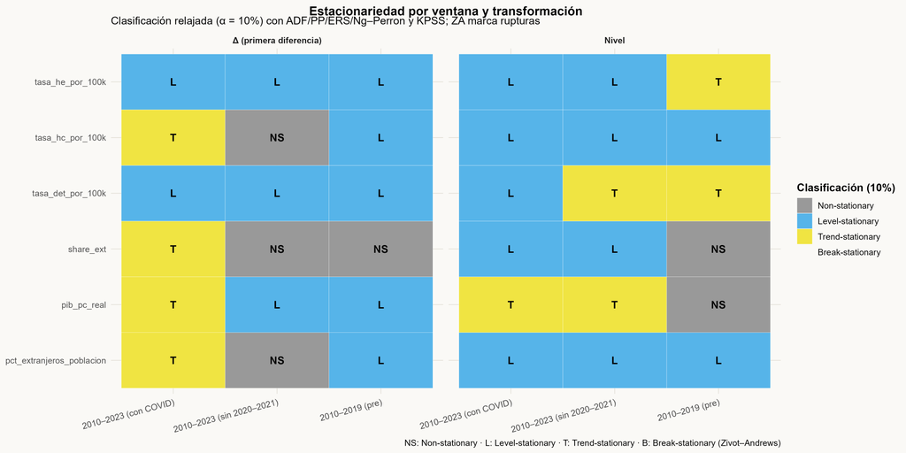

Estacionariedad — α = 10%

# 11 Citación y licencias

## 11.1 Cómo citar este proyecto

> **Castro, J. (2025). *Delitos e Inmigración en España (2010–2023).* JESUSCASTRODATA (GitHub).** https://doi.org/10.5281/zenodo.17465216 · Código bajo MIT · Documentación y figuras bajo CC BY 4.0.

## 11.2 Licencias aplicables

### 11.2.1 Código fuente

El código del proyecto se distribuye bajo la **Licencia MIT**, que permite su uso, copia, modificación y redistribución con atribución al autor original.

**Licencia:** [MIT License](https://opensource.org/licenses/MIT) **Autor:** © 2025 Jesús Castro · JESUSCASTRODATA

### 11.2.2 Documentos, figuras y materiales visuales

Los contenidos textuales, visuales y gráficos del informe están disponibles bajo una **licencia Creative Commons Atribución 4.0 Internacional (CC BY 4.0)**, que permite compartir y adaptar el material siempre que se cite adecuadamente al autor.

**Licencia:** [CC BY 4.0](https://creativecommons.org/licenses/by/4.0/) **Atribución sugerida:** *Castro, J. (2025).* Delitos e Inmigración en España (2010–2023).* Documentos y figuras bajo CC BY 4.0.*

### 11.2.3 Datos originales

Los **datos fuente** utilizados en este proyecto (INE, Ministerio del Interior, Eurostat) mantienen sus propias condiciones de uso y reutilización según las políticas de cada organismo. Para conocer los detalles específicos, consulte el documento: `docs/DATOS_Y_LICENCIAS.md`.

### 11.2.4 Créditos y resumen legal

© 2024–2025 Jesús Castro · JESUSCASTRODATA **Licencias:** MIT (código) · CC BY 4.0 (documentación y figuras) · Datos: según condiciones originales de cada fuente. **DOI:** 10.5281/zenodo.17465216